# The Oil Fatty Acid Composition Viewer and Mixing Simulator

Feature Guide - 6/21/2017

# View an oil’s fatty acid “fingerprint”

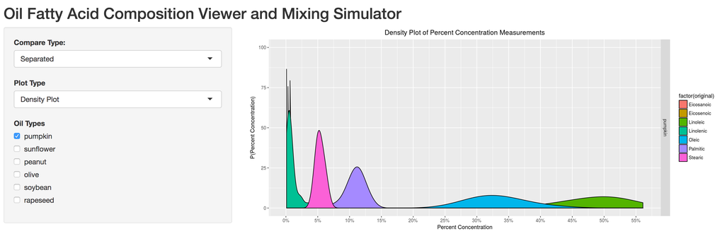

* Use density plots to explore the probabilities for percent concentration of each fatty acid type!  
* It looks like pumpkin oil is typically composed of high concentrations of Linoleic (around 50%) and Oleic (around 33%) acid!

# Compare multiple oils at once

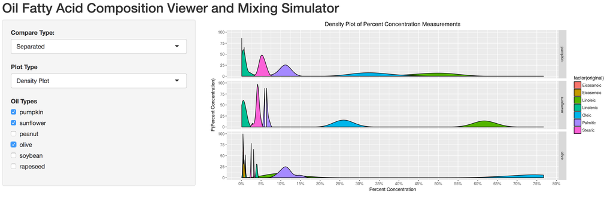

* Using faceting, multiple oils can be compared at the same time!  
* Pumpkin and sunflower oil have similar compositions  
* Olive oil is very different, however. Olive oil has much more Oleic acid than the two other oils!

# View the likely concentrations with box plots too

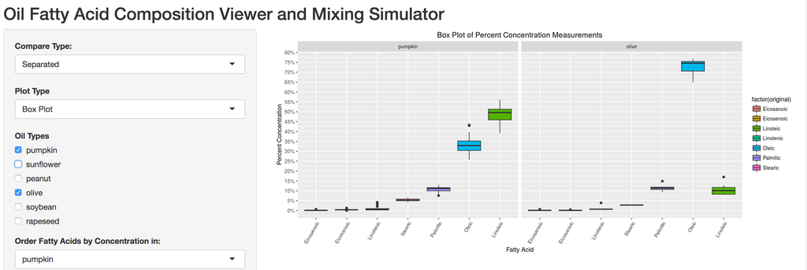

* Since the faceted graphs share the same y-axis, it is easy to look right across to compare the range of fatty acid concentrations  
* Choose which oil to order the x-axis by. In this case, the x-axis is ordered by fatty acid concentrations of pumpkin oil.  
* Quickly see how the rank of highest concentrated fatty acid is Linoleic acid for pumpkin oil versus Oleic acid for olive oil

# Simulate a 1:1 mixing of multiple oils

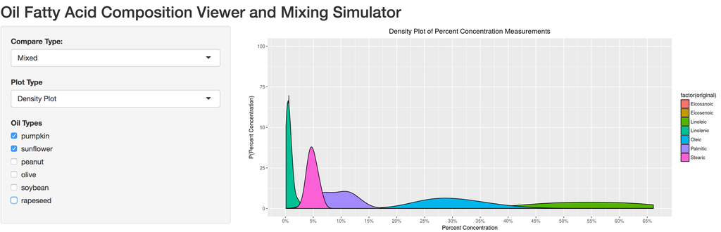

* Combine all the data points from multiple oils to see the likely compositions if one mixed the oils equally with each other  
* A mix between sunflower and pumpkin oil has a wide range of possible values for Oleic and Linoleic acid, while Stearic and Linolenic acid concentrations would not vary by much.